# Final Project - Top 1000 Movies by IMDB Rating

```r
decade_long <- decade_gross%>%
  pivot_longer(
    cols = c(Average_Gross, Average_Adjusted_Gross),
    names_to = "Type",
    values_to = "Gross"
  )%>%
  mutate(Type =recode(Type,
                      "Average_Gross" = "Nominal Gross", "Average_Adjusted_Gross" = "Ajusted Gross (2024)" ))

g <- ggplot(decade_long, aes(x= Decade, y = Gross, colour  =Type))+ geom_line(linewidth = 1.0)+ geom_point(size =3) + labs( title = "Average box office by decade", subtitle = "Nominal vs. Inflation-Adjsuted to 2024 USD", x = "Decade", y = "Average Gross (Millions USD") + theme_minimal()

ggplotly(g)
```

[interactive chart not shown]

Top 10 Director & Lead Actor Pairs among Top 1000 IMDB Rated Movies (Joseph Godinez)

[figure not shown]

```r
pair_data <- my_data %>%
  group_by(Director, Star1) %>%
  summarise(Movie_Count = n(), .groups = "drop") %>%
  slice_max(Movie_Count, n = 10) %>%
  mutate(Pair = paste(Director, "+", Star1))

ggplot(pair_data, aes(x = reorder(Pair, Movie_Count), y = Movie_Count, fill = Movie_Count)) +
  geom_col(width = 0.5) +  geom_text(aes(label = paste(Movie_Count, "films")), hjust = -0.2, size = 3.5) +
  coord_flip() +
  scale_y_continuous(expand = expansion(mult = c(0, 0.3))) + labs(title = "Top 10 Director & Lead Actor Pairs",
    subtitle = "Among Top 1000 IMDB Rated Movies",
    x = NULL,
    y = "Number of Movies Together"
  ) +theme_minimal(base_size = 12)
```

How does the distribution of ratings compare across decades? (Joseph Godinez)

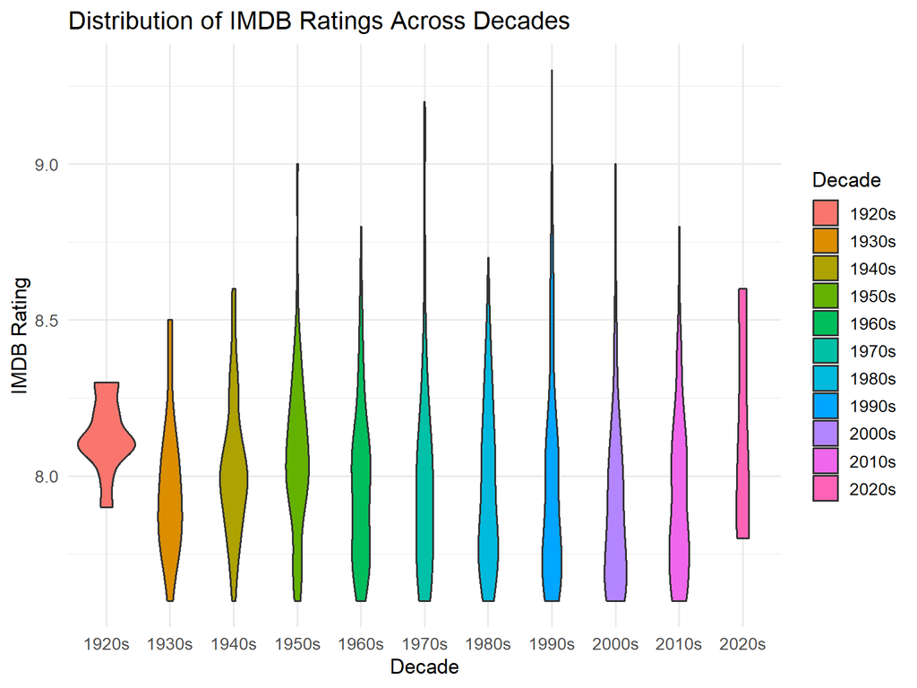

```r
decade_data <- my_data %>%
  mutate(Decade = paste0((Released_Year %/% 10) * 10, "s")) %>%
group_by(Decade) %>%
  filter(n() >= 5)%>%
  ungroup()

ggplot(decade_data, aes(x = Decade, y = IMDB_Rating, fill = Decade)) +
  geom_violin() + labs(title = "Distribution of IMDB Ratings Across Decades", x = "Decade", y = "IMDB Rating") + theme_minimal(base_size = 13)
```

What is the relationship between ratings and runtime?

[figure not shown]

```r
my_data <- my_data%>%
  mutate(Runtime = as.numeric(gsub(" min", "", Runtime)))

ggplot(my_data, aes(x = Runtime, y = IMDB_Rating)) +
  geom_point(alpha = 0.6) +
  labs(
    title = "People's Rating vs Runtime",
    x = "Runtime",
    y = "IMDb Rating"
  )
```

[figure not shown]

```r
ggplot(my_data, aes(x = Runtime, y = Meta_score)) +
  geom_point(alpha = 0.6) +
  labs(
    title = "Critics Score vs Runtime",
    x = "Runtime",
    y = "Meta_score"
  )
```

2. Which genres tend to have the longest runtime?

```r
my_data <- my_data %>%
  mutate(Runtime = as.numeric(gsub("[^0-9]", "", Runtime)))

my_data_genre <- my_data %>%
  separate_rows(Genre, sep = ", ")

genre_runtime <- my_data_genre %>%
  group_by(Genre) %>%
  summarize(avg_runtime = mean(Runtime, na.rm = TRUE)) %>%
  arrange(desc(avg_runtime))

head(genre_runtime)
```

```
## # A tibble: 6 × 2
##   Genre     avg_runtime
##   <chr>           <dbl>
## 1 Action            NaN
## 2 Adventure         NaN
## 3 Animation         NaN
## 4 Biography         NaN
## 5 Comedy            NaN
## 6 Crime             NaN
```

[figure not shown]

```r
ggplot(genre_runtime, aes(x = reorder(Genre, avg_runtime), y = avg_runtime)) +
  geom_col() +
  coord_flip() +
  labs(
    title = "Average Runtime by Genre",
    x = "Genre",
    y = "Average Runtime (minutes)"
  )
```

3. Which genre produces the most highly-rated movies (rating > 8.5)?

```r
high_rated <- my_data %>%
  filter(IMDB_Rating > 8.5)

high_rated_genre <- high_rated %>%
  separate_rows(Genre, sep = ", ")

genre_counts <- high_rated_genre %>%
  group_by(Genre) %>%
  summarize(count = n()) %>%
  arrange(desc(count))

head(genre_counts)
```

```
## # A tibble: 6 × 2
##   Genre     count
##   <chr>     <int>
## 1 Drama        27
## 2 Action       10
## 3 Crime        10
## 4 Adventure     9
## 5 Fantasy       4
## 6 Biography     3
```

[figure not shown]

```r
ggplot(genre_counts, aes(x = reorder(Genre, count), y = count)) +
  geom_col() +
  coord_flip() +
  labs(
    title = "Number of Highly Rated Movies (IMDb > 8.5) by Genre",
    x = "Genre",
    y = "Count of Movies"
  )
```

7. Which Director and Lead Actor work together most often? (Rakendra S.)

```r
# Finding the most frequent pairings
top_duos <- my_data %>%
  group_by(Director, Star1) %>%
  summarise(movie_count = n(), .groups = 'drop') %>%
  arrange(desc(movie_count)) %>%
  head(5)

#  Plot
p1 <- ggplot(top_duos, aes(x = movie_count, y = reorder(paste(Director, "&", Star1), movie_count), fill = Director)) +
  geom_col() +
  labs(title = "Top 5 Director & Actor Pairings", x = "Number of Movies Together", y = "Partnership") +
  theme_minimal() +
  theme(legend.position = "none")

ggplotly(p1)
```

[interactive chart not shown]

8. Do movies with the most votes have the highest ratings? (Rakendra S.)

```r
p3 <- ggplot(my_data, aes(x = No_of_Votes, y = IMDB_Rating, text = Series_Title)) +
  geom_point(alpha = 0.4, color = "black") +
  geom_smooth(method = "lm", color = "red") +
  labs(title = "Number of Votes vs. IMDB Rating", x = "Number of Votes", y = "IMDB Rating") +
  theme_light()


ggplotly(p3, tooltip = "text")
```

[interactive chart not shown]

9. Has the “Golden Age” passed? Average Ratings over the Decades. Does people rated older movie more or new ones (Rakendra S.)

```r
# Cleaning years and grouping by Decade
decade_trends <- my_data %>%
  mutate(Year = as.numeric(gsub("[^0-9]", "", Released_Year))) %>%
  filter(!is.na(Year)) %>%
  mutate(Decade = (Year %/% 10) * 10) %>%
  group_by(Decade) %>%
  summarise(avg_rating = mean(IMDB_Rating, na.rm = TRUE))

# Line graph for trends
p5 <- ggplot(decade_trends, aes(x = Decade, y = avg_rating)) +
  geom_line(size = 1, color = "black") +
  geom_point(size = 2) +
  labs(title = "Average IMDB Rating by Decade", x = "Decade", y = "Average Rating") +
  theme_minimal()

ggplotly(p5)
```

[interactive chart not shown]

10. Which 5 Directors have earned the most Total Gross? (Rakendra S.)

```r
director_wealth <- my_data %>%
  mutate(Gross_Clean = as.numeric(gsub(",", "", Gross))) %>%
  filter(!is.na(Gross_Clean)) %>%
  group_by(Director) %>%
  summarise(
    Total_Movies = n(),
    Total_Gross_Millions = sum(Gross_Clean, na.rm = TRUE) / 1000000,
    Average_IMDB = mean(IMDB_Rating, na.rm = TRUE)
  ) %>%
  arrange(desc(Total_Gross_Millions)) %>%
  head(5)

print(director_wealth)
```

```
## # A tibble: 5 × 4
##   Director          Total_Movies Total_Gross_Millions Average_IMDB
##   <chr>                    <int>                <dbl>        <dbl>
## 1 Steven Spielberg            13                2478.         8.03
## 2 Anthony Russo                4                2205.         8.07
## 3 Christopher Nolan            8                1937.         8.46
## 4 James Cameron                5                1748.         8.08
## 5 Peter Jackson                5                1597.         8.4
```

11. What is the most common IMDB rating? (Rakendra S.)

```r
# We use a binwidth of 0.1 because ratings are close  (8.1, 8.2, etc.)
p_rating_hist <- ggplot(my_data, aes(x = IMDB_Rating)) +
  geom_histogram(binwidth = 0.1, fill = "red", color = "black") +
  labs(
    title = "Distribution of IMDB Ratings",
    x = "IMDB Rating",
    y = "Number of Movies"
  ) +
  theme_minimal()


ggplotly(p_rating_hist)
```

[interactive chart not shown]